# Introduction to Plotting in R

Barboza-Salerno

2024-01-05

# Introduction

This script demonstrates basic plotting in R base

## Creating a dataset

This demonstrates how to create a dataset in R. This will be the only time we do this, from now on we will import data in the form of .csv, .sav, .dta, .xlsx, or .sasbat.

```r
sex_at_birth <- c("male", "male", "female", "male", "female", "female")
age <- c(10, 12, 3, 0, 1, 16)
cbl_score <- c(50, 39, 48, 54, 70, 55)
dep_score <- c(40, 29, 37, 44, 60, 45)
total_score <- cbl_score + dep_score
mydat <- data.frame(sex_at_birth, age, cbl_score, dep_score, total_score)
View(mydat)
```

## Boxplots

The boxplot() function can be used to create box plots.

The following command generates a box plot for age in our data:

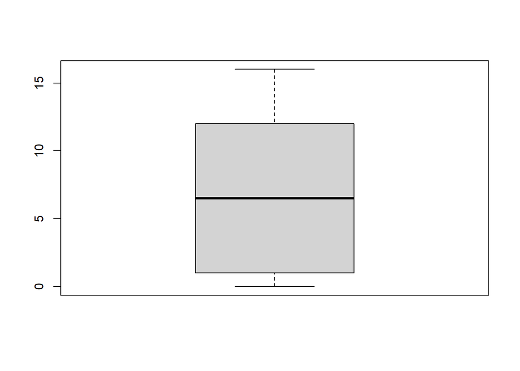

```r
boxplot(mydat$age)
```

Now, we change the x-axis label:

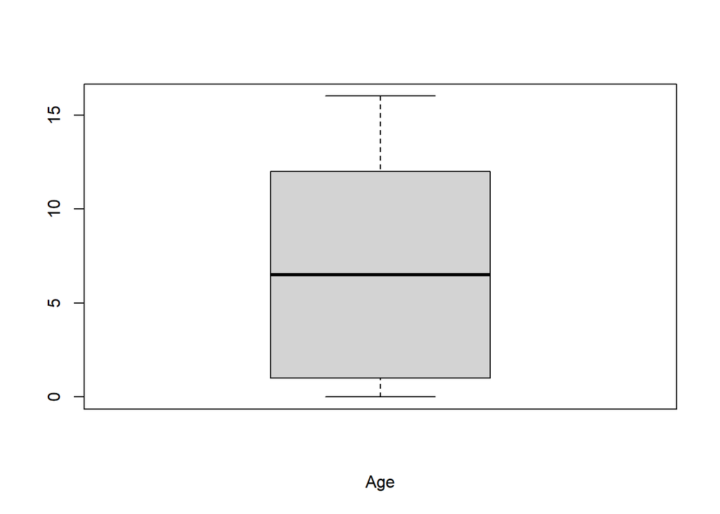

```r
boxplot(mydat$age, xlab = "Age")
```

Now, we change the color

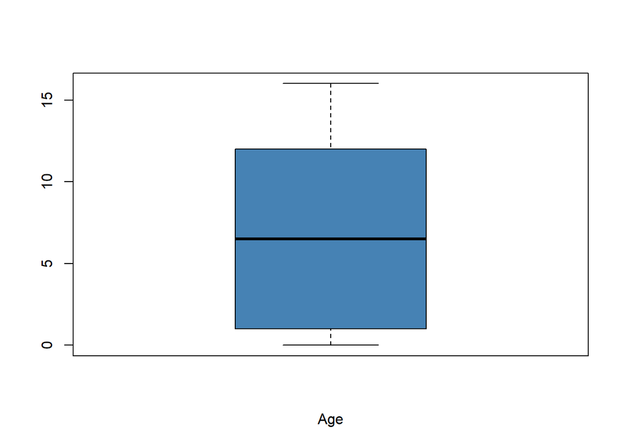

```r
boxplot(mydat$age, xlab = "Age", col = "steelblue")
```

We can also split the box plots by groups. For example, the command

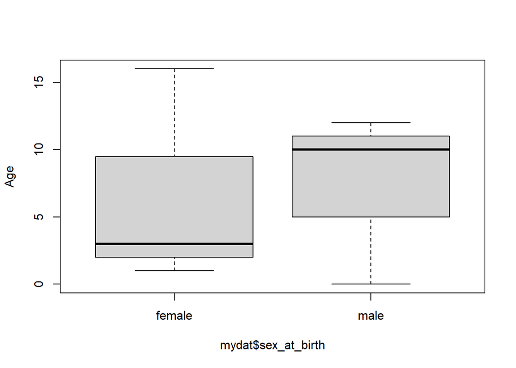

```r
boxplot(mydat$age ~ mydat$sex_at_birth,  ylab="Age")
```

Now we can use the boxplot() attributes to make a nice looking boxplot: Below we - first remove the data$ from the labels and add the data attribute explicitly - then we change the color - then we change the color by **sex_at_birth** - then we relabel the boxes by color of **sex_at_birth**

*Note* Please do NOT think you will understand all of this immediately. If you want to learn it, take it step-by-step and understand what each command is doing before moving on!

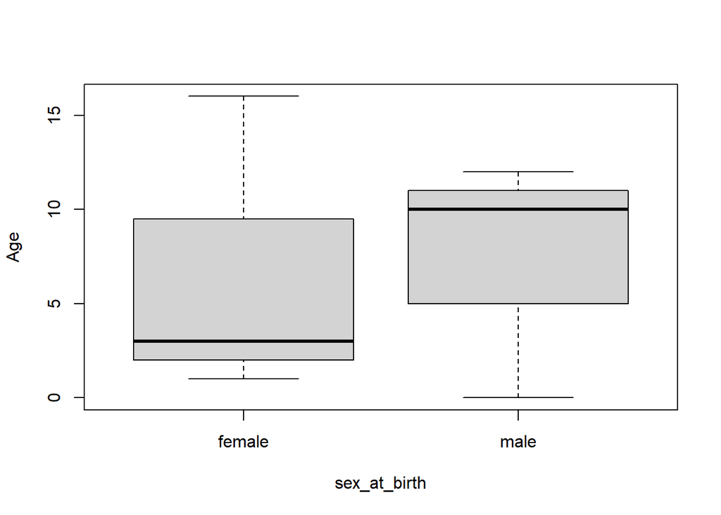

```r
boxplot(age ~ sex_at_birth, data=mydat, ylab="Age")
```

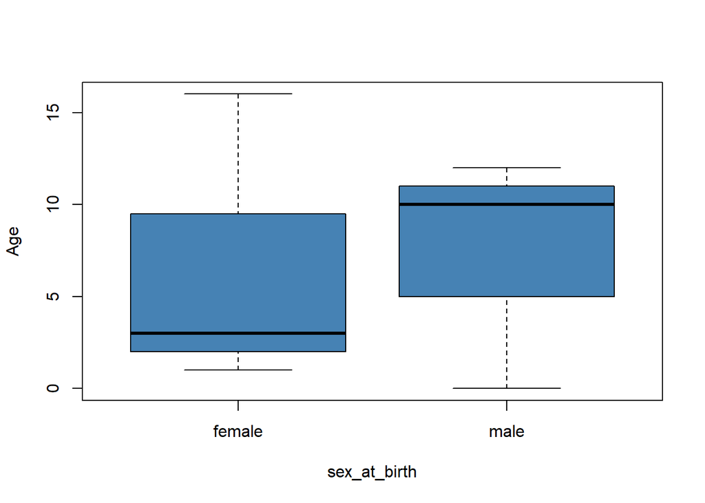

```r
boxplot(age ~ sex_at_birth, data=mydat, ylab="Age", col="steelblue")
```

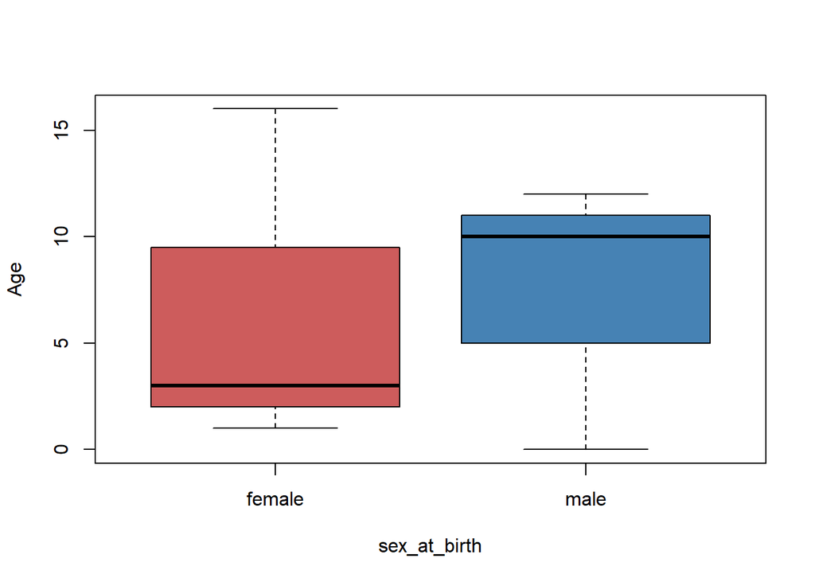

```r
boxplot(age ~ sex_at_birth, data=mydat, ylab="Age", col=c("indianred", "steelblue"))
```

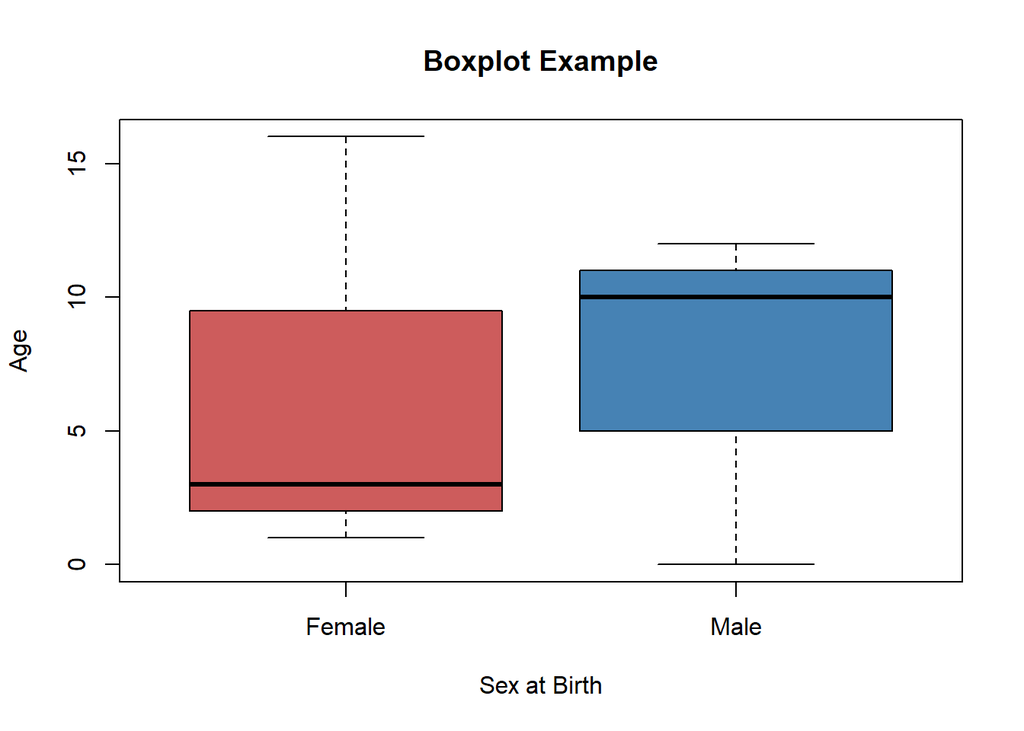

```r
boxplot(age ~ sex_at_birth,
        data=mydat,
        ylab="Age", xlab = "Sex at Birth",
        col=c("indianred", "steelblue"),
        names = c("Female", "Male"),
        main = "Boxplot Example")
```

# Scatterplots

Another commonly-used plot is a scatter plot. It is a plot of data points of one variable versus another. To plot the cbl scores versus depressive symptoms scores, we use the command:

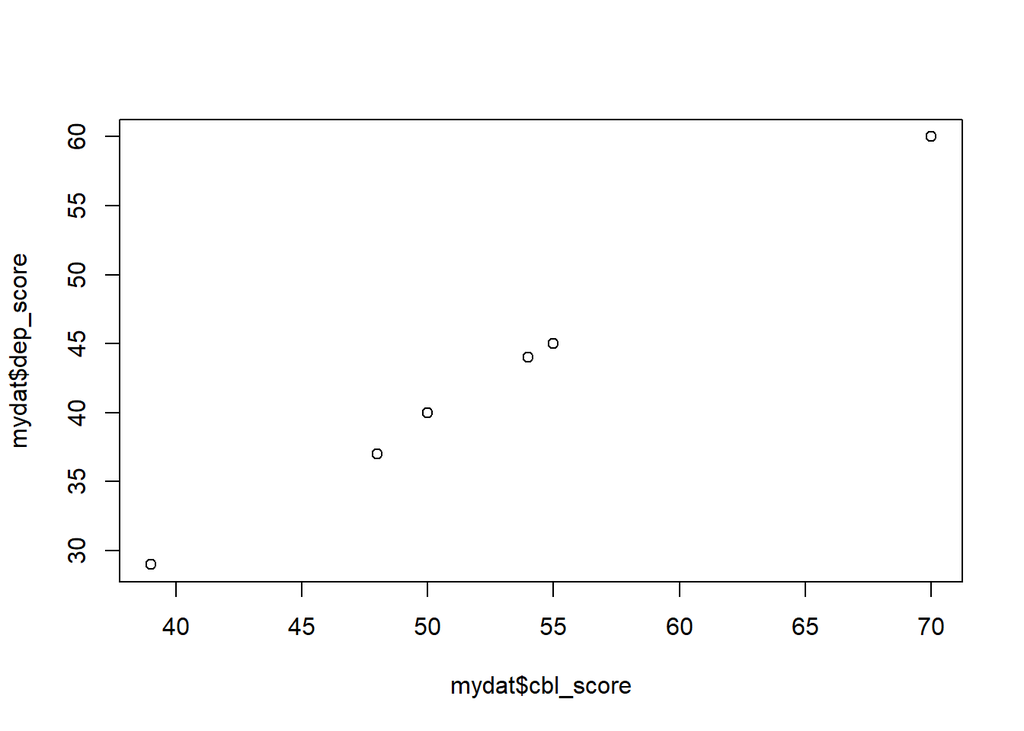

```r
plot(mydat$cbl_score, mydat$dep_score)
```

### Point-Type Parameter pch

By default, each point is represented by an open circle. This can be changed by setting the pch parameter. We can also change the axis labels using the xlab and ylab commands:

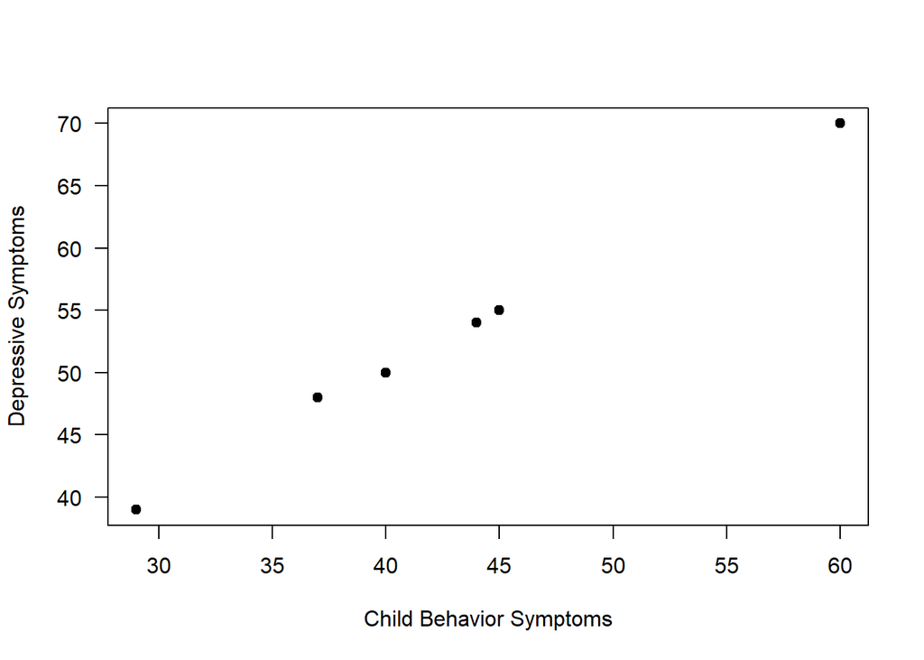

```r
plot(cbl_score ~ dep_score, data=mydat, pch=19, ylab="Depressive Symptoms",
     xlab="Child Behavior Symptoms", las=1)
```

We see that the pch=19 option sets the points to be filled circles, and the las=1 option makes the y-axis numeric labels perpendicular to the y-axis. Other pch values correspond to other point types, and you can look them up [here](https://www.ling.upenn.edu/~joseff/rstudy/week4.html#pch). Actually, there is an easy way to look it up. Just type the command

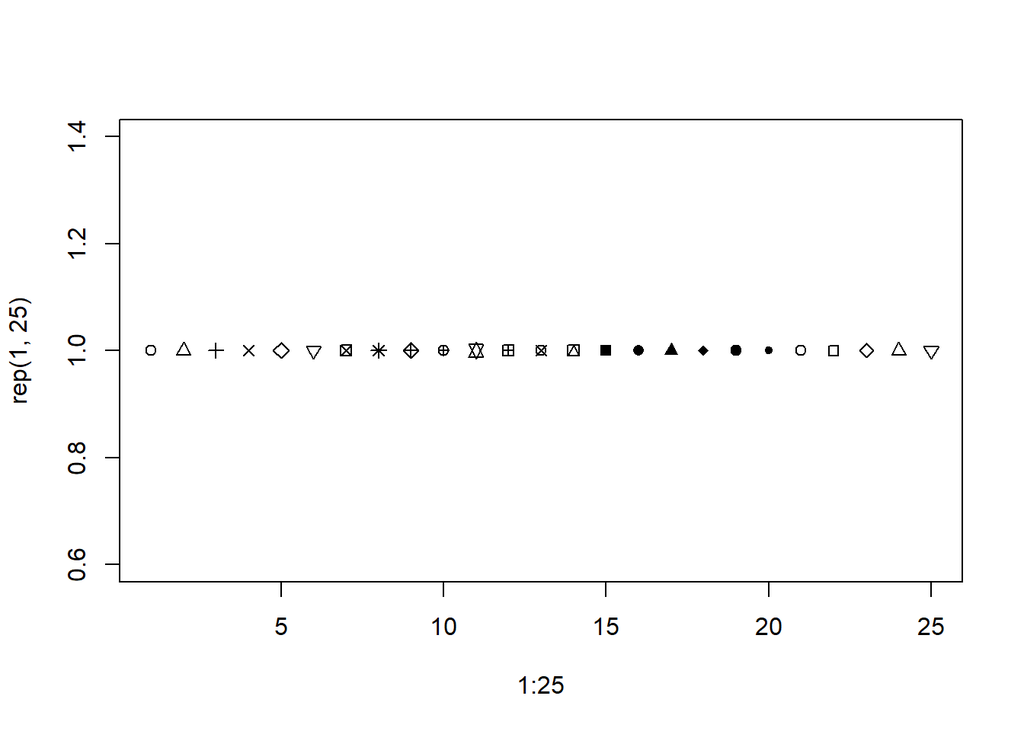

```r
plot(1:25,rep(1,25),pch=1:25)
```

It plots the points (1,1), (2,1), (3,1), …, (25,1), with the first point having pch=1, second point with pch=2 and so on.

Now we can add color and other options as above. Note, the options are the same for ALL Base R plots (i.e., histograms, barcharts, plots, boxplots, etc.)

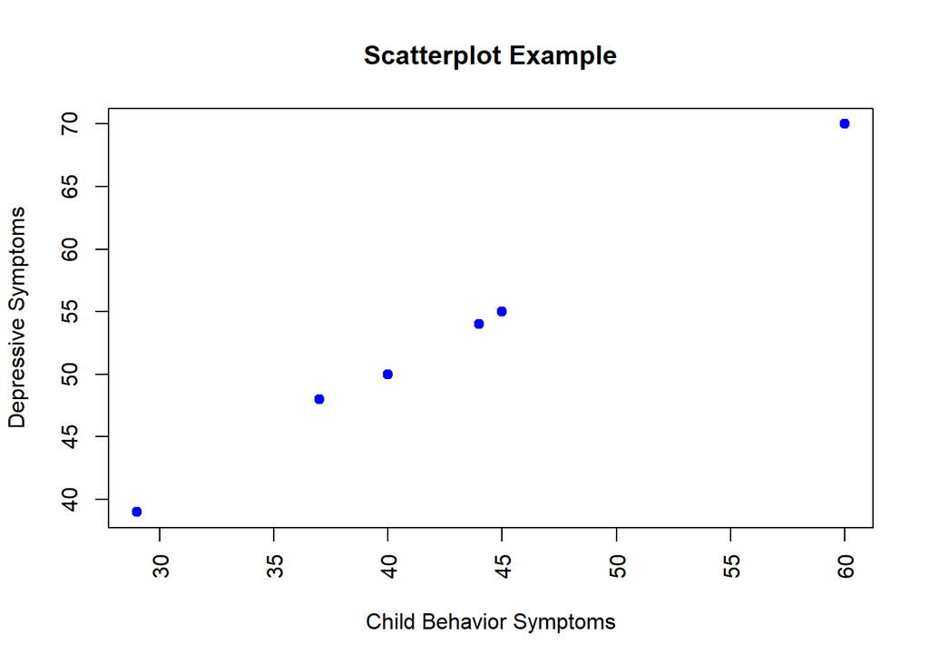

```r
plot(cbl_score ~ dep_score,
     data=mydat, pch=19, col="blue",
     ylab="Depressive Symptoms",
     xlab="Child Behavior Symptoms",
     las=3,
     main = "Scatterplot Example")
```

Now let’s color the scatterplot by sex at birth. To do so, R requires the categorical data to be represented as a factor. We can transform the variable in the plot itself (as I do below).

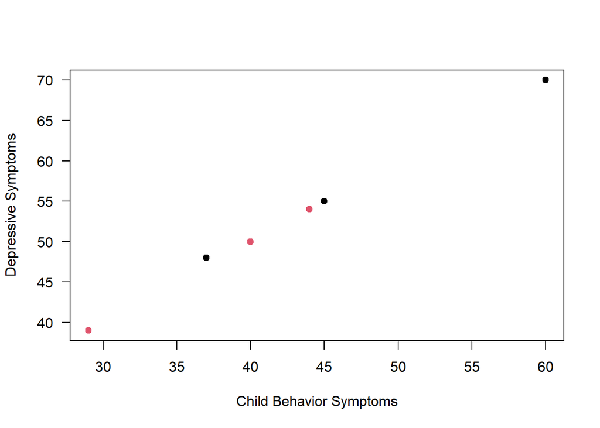

```r
plot(cbl_score ~ dep_score, data=mydat, pch=19,
     col=as.factor(sex_at_birth),
     ylab="Depressive Symptoms",
     xlab="Child Behavior Symptoms", las=1)
```

We can also change the variable in the dataset from character to factor and then plot it (this is easier).

```r
(mydat$sex_at_birth <- as.factor(mydat$sex_at_birth))
```

```
## [1] male   male   female male   female female
## Levels: female male
```

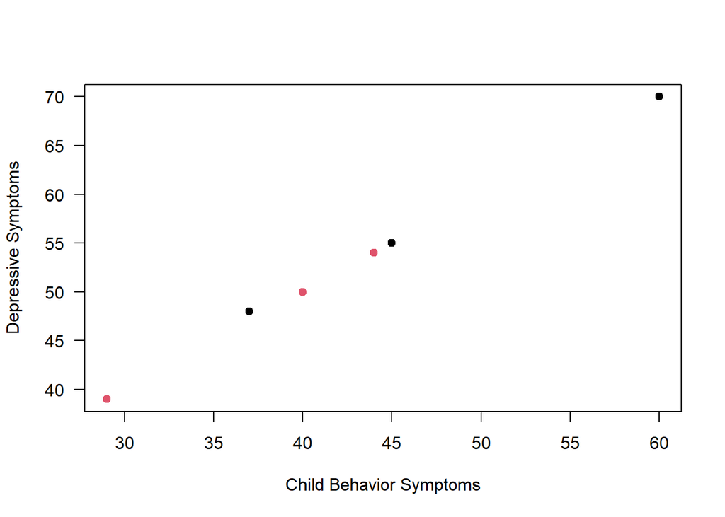

```r
plot(cbl_score ~ dep_score, data=mydat, pch=19,
     col=sex_at_birth,
     ylab="Depressive Symptoms",
     xlab="Child Behavior Symptoms", las=1)
```

## CHALLENGE

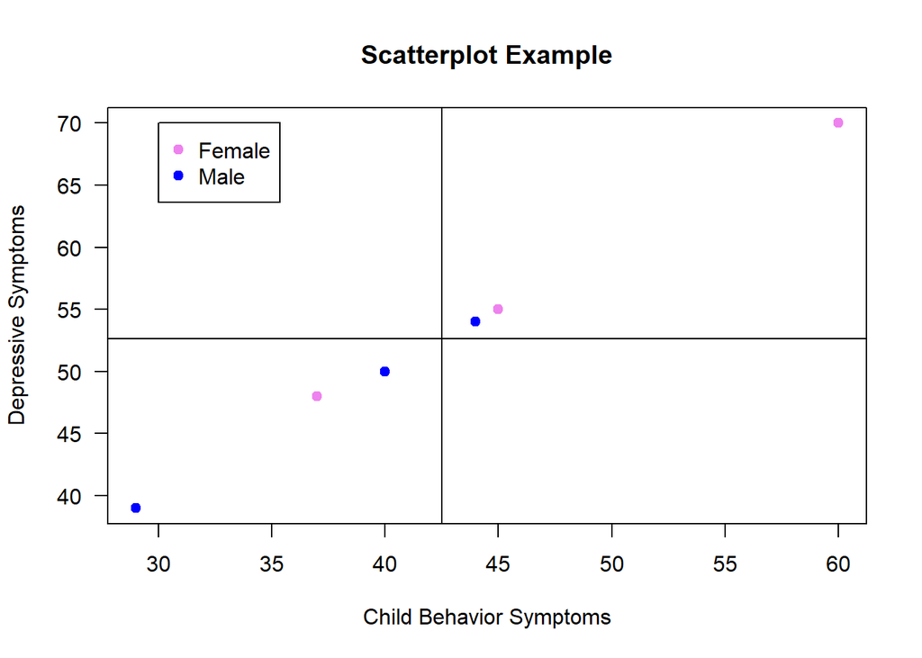

```r
plot(cbl_score ~ dep_score, data=mydat, pch=19,
     col = c("violet", "blue")[as.factor(mydat$sex_at_birth)],
     ylab="Depressive Symptoms",
     xlab="Child Behavior Symptoms", las=1,
     main = "Scatterplot Example")
legend(30,70,c("Female","Male"),col=c("violet", "blue"),pch=19)
abline(h=mean(mydat$cbl_score),v=mean(mydat$dep_score))
```

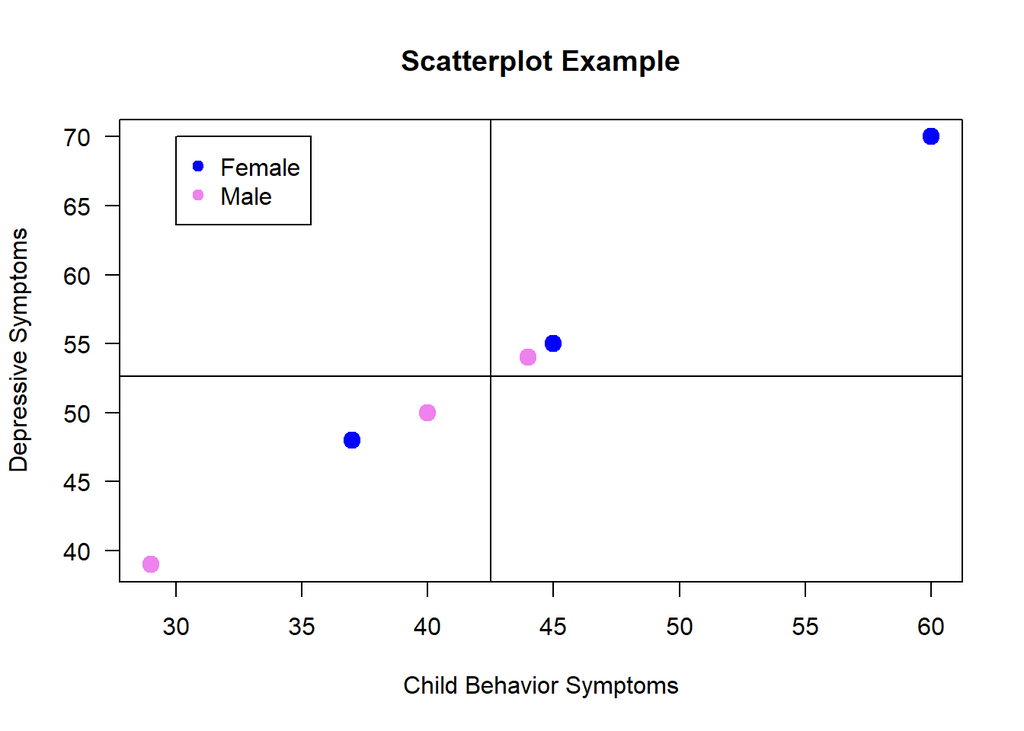

```r
plot(cbl_score ~ dep_score, data=mydat, pch=19,
     col = c("blue", "violet")[mydat$sex_at_birth],
     ylab="Depressive Symptoms",
     xlab="Child Behavior Symptoms", las=1, cex = 1.5,
     main = "Scatterplot Example")
legend(30,70,c("Female","Male"),col=c("blue", "violet"),pch=19)
abline(h=mean(mydat$cbl_score),v=mean(mydat$dep_score))
```

```r
c("blue", "violet")[mydat$sex_at_birth]
```

```
## [1] "violet" "violet" "blue"   "violet" "blue"   "blue"
```

```r
mydat$sex_at_birth
```

```
## [1] male   male   female male   female female
## Levels: female male
```

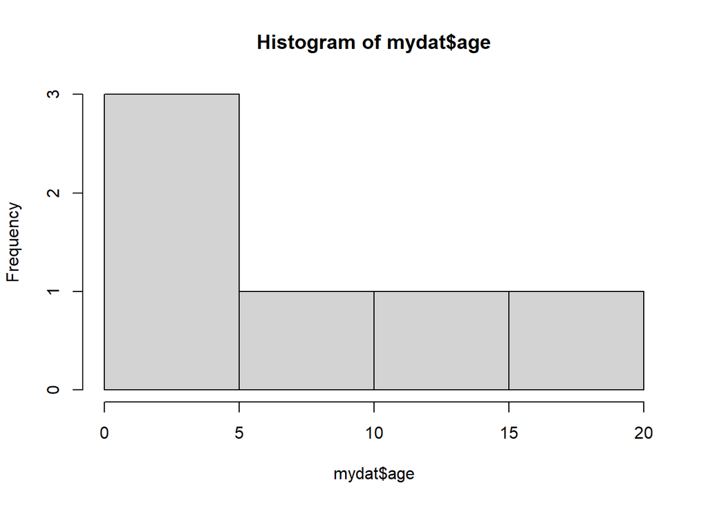

```r
hist(mydat$age)
```

```r
# in the R console type ?hist to bring up the help screen
# fancy the hist of age

table(mydat$sex_at_birth)
```

```
##
## female   male
##      3      3
```

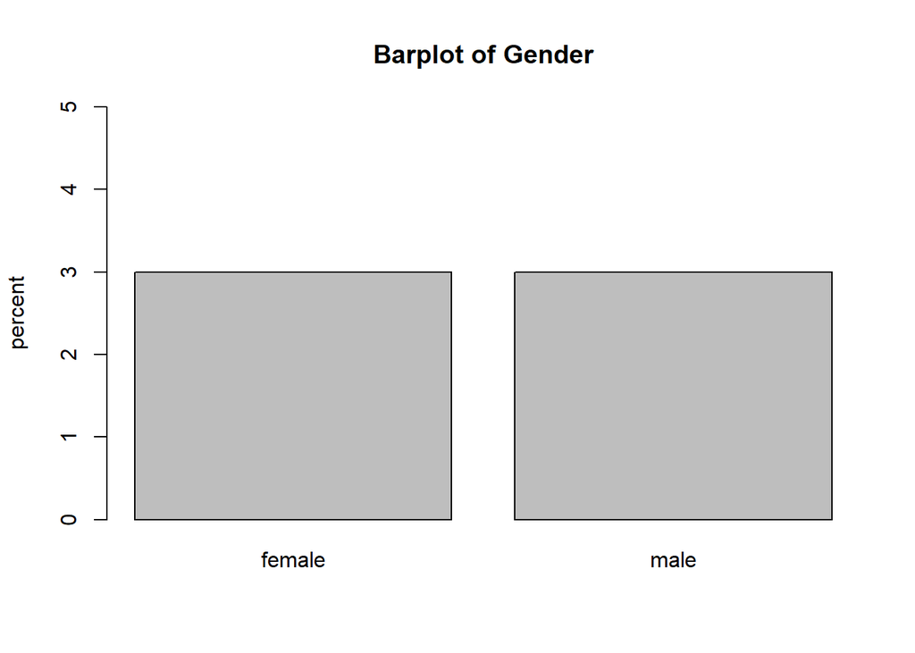

```r
barplot(table(mydat$sex_at_birth),ylim=c(0,5), ylab="percent",main="Barplot of Gender")
```

## Writing and Reading Data

We can save the datafile to the computer for later as follows:

```r
write.csv(mydat, "mydat.csv")
```

The default is to save the file to the working directory. So, it is useful to set the working directory at the outset. My working directory is

```r
getwd()
```

```
## [1] "C:/Users/barboza-salerno.1/evalsp23.classes.andrewheiss.com/slides"
```

Now, let’s read the csv file and re-run all charts…

```r
mydat <- read.csv("mydat.csv")
```